# CARDIOVASCULAR DISEASE : ANALYSIS OF CAUSES AND PREDICTION

### Distribution Plot of cholesterol levels vs ap_hi (systolic blood pressure) who consume alcohol w.r.t disease

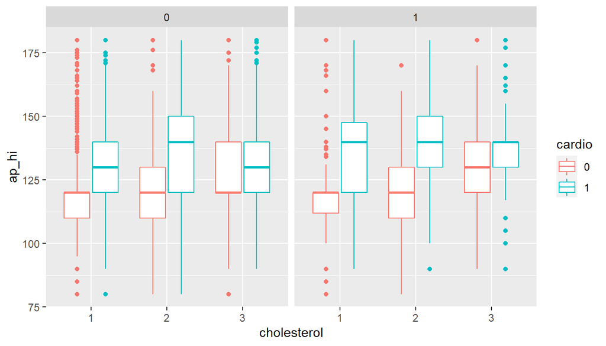

```r
ggplot(cleaned_cardio,aes(cholesterol,ap_hi))+geom_boxplot(aes(color=cardio))+facet_wrap(alco~.)
```

```r
#People with 2nd cholesterol level having the disease were found with maximum systolic blood pressure.
```

### Distribution Plot of cholesterol levels vs ap_hi (systolic blood pressure) who smoke w.r.t disease

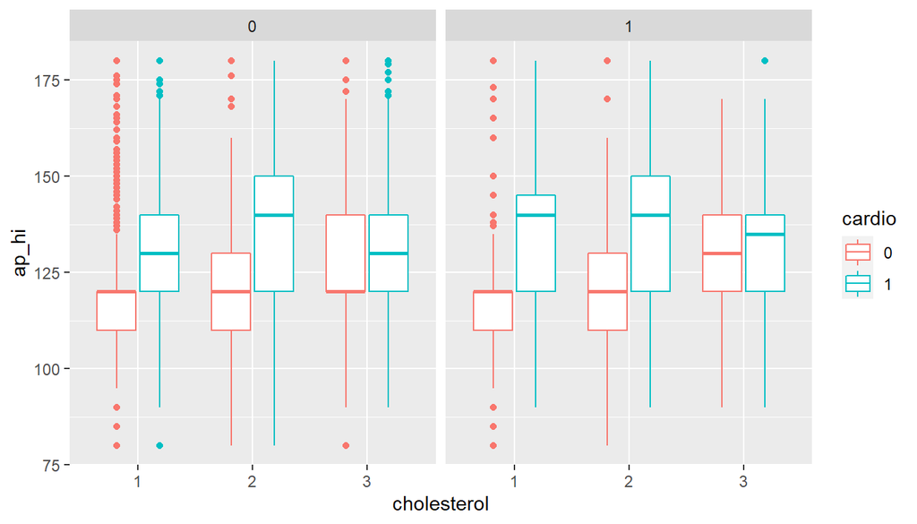

```r
ggplot(cleaned_cardio,aes(cholesterol,ap_hi))+geom_boxplot(aes(color=cardio))+facet_wrap(smoke~.)
```

```r
#People with 2nd cholesterol level having the disease were found with maximum systolic blood pressure.
```